# Python_Final_50

## 1) Import File

```python
import pandas as pd
import nbconvert as nbconvert

df = pd.read_csv("C:/Users/vmele/Downloads/banklist.csv", encoding = "ISO-8859-1")

import plotly
plotly.tools.set_credentials_file(username='vmelednezg2', api_key='WYuZ0x5v2VOgHN5I6RCX')
import plotly.plotly as py
import datetime
```

```python
df
```

|  | Bank Name | City | ST | CERT | Acquiring Institution | Closing Date | Updated Date |
| --- | --- | --- | --- | --- | --- | --- | --- |
| 0 | Washington Federal Bank for Savings | Chicago | IL | 30570 | Royal Savings Bank | 15-Dec-17 | 21-Feb-18 |
| 1 | The Farmers and Merchants State Bank of Argonia | Argonia | KS | 17719 | Conway Bank | 13-Oct-17 | 21-Feb-18 |
| 2 | Fayette County Bank | Saint Elmo | IL | 1802 | United Fidelity Bank, fsb | 26-May-17 | 26-Jul-17 |
| 3 | Guaranty Bank, (d/b/a BestBank in Georgia & Mi... | Milwaukee | WI | 30003 | First-Citizens Bank & Trust Company | 5-May-17 | 22-Mar-18 |
| 4 | First NBC Bank | New Orleans | LA | 58302 | Whitney Bank | 28-Apr-17 | 5-Dec-17 |
| 5 | Proficio Bank | Cottonwood Heights | UT | 35495 | Cache Valley Bank | 3-Mar-17 | 7-Mar-18 |
| 6 | Seaway Bank and Trust Company | Chicago | IL | 19328 | State Bank of Texas | 27-Jan-17 | 18-May-17 |
| 7 | Harvest Community Bank | Pennsville | NJ | 34951 | First-Citizens Bank & Trust Company | 13-Jan-17 | 18-May-17 |
| 8 | Allied Bank | Mulberry | AR | 91 | Today's Bank | 23-Sep-16 | 25-Sep-17 |
| 9 | The Woodbury Banking Company | Woodbury | GA | 11297 | United Bank | 19-Aug-16 | 1-Jun-17 |
| 10 | First CornerStone Bank | King of Prussia | PA | 35312 | First-Citizens Bank & Trust Company | 6-May-16 | 6-Sep-16 |
| 11 | Trust Company Bank | Memphis | TN | 9956 | The Bank of Fayette County | 29-Apr-16 | 6-Sep-16 |
| 12 | North Milwaukee State Bank | Milwaukee | WI | 20364 | First-Citizens Bank & Trust Company | 11-Mar-16 | 13-Mar-17 |
| 13 | Hometown National Bank | Longview | WA | 35156 | Twin City Bank | 2-Oct-15 | 19-Feb-18 |
| 14 | The Bank of Georgia | Peachtree City | GA | 35259 | Fidelity Bank | 2-Oct-15 | 9-Jul-18 |
| 15 | Premier Bank | Denver | CO | 34112 | United Fidelity Bank, fsb | 10-Jul-15 | 20-Feb-18 |
| 16 | Edgebrook Bank | Chicago | IL | 57772 | Republic Bank of Chicago | 8-May-15 | 12-Jul-16 |
| 17 | Doral Bank | San Juan | PR | 32102 | Banco Popular de Puerto Rico | 27-Feb-15 | 13-May-15 |
| 18 | Capitol City Bank & Trust Company | Atlanta | GA | 33938 | First-Citizens Bank & Trust Company | 13-Feb-15 | 21-Apr-15 |
| 19 | Highland Community Bank | Chicago | IL | 20290 | United Fidelity Bank, fsb | 23-Jan-15 | 15-Nov-17 |
| 20 | First National Bank of Crestview | Crestview | FL | 17557 | First NBC Bank | 16-Jan-15 | 15-Nov-17 |
| 21 | Northern Star Bank | Mankato | MN | 34983 | BankVista | 19-Dec-14 | 3-Jan-18 |
| 22 | Frontier Bank, FSB D/B/A El Paseo Bank | Palm Desert | CA | 34738 | Bank of Southern California, N.A. | 7-Nov-14 | 10-Nov-16 |
| 23 | The National Republic Bank of Chicago | Chicago | IL | 916 | State Bank of Texas | 24-Oct-14 | 6-Jan-16 |
| 24 | NBRS Financial | Rising Sun | MD | 4862 | Howard Bank | 17-Oct-14 | 19-Feb-18 |
| 25 | GreenChoice Bank, fsb | Chicago | IL | 28462 | Providence Bank, LLC | 25-Jul-14 | 12-Dec-16 |
| 26 | Eastside Commercial Bank | Conyers | GA | 58125 | Community & Southern Bank | 18-Jul-14 | 6-Oct-17 |
| 27 | The Freedom State Bank | Freedom | OK | 12483 | Alva State Bank & Trust Company | 27-Jun-14 | 21-Feb-18 |
| 28 | Valley Bank | Fort Lauderdale | FL | 21793 | Landmark Bank, National Association | 20-Jun-14 | 14-Feb-18 |
| 29 | Valley Bank | Moline | IL | 10450 | Great Southern Bank | 20-Jun-14 | 26-Jun-15 |
| ... | ... | ... | ... | ... | ... | ... | ... |
| 525 | ANB Financial, NA | Bentonville | AR | 33901 | Pulaski Bank and Trust Company | 9-May-08 | 28-Aug-12 |
| 526 | Hume Bank | Hume | MO | 1971 | Security Bank | 7-Mar-08 | 28-Aug-12 |
| 527 | Douglass National Bank | Kansas City | MO | 24660 | Liberty Bank and Trust Company | 25-Jan-08 | 26-Oct-12 |
| 528 | Miami Valley Bank | Lakeview | OH | 16848 | The Citizens Banking Company | 4-Oct-07 | 12-Sep-16 |
| 529 | NetBank | Alpharetta | GA | 32575 | ING DIRECT | 28-Sep-07 | 28-Aug-12 |
| 530 | Metropolitan Savings Bank | Pittsburgh | PA | 35353 | Allegheny Valley Bank of Pittsburgh | 2-Feb-07 | 27-Oct-10 |
| 531 | Bank of Ephraim | Ephraim | UT | 1249 | Far West Bank | 25-Jun-04 | 9-Apr-08 |
| 532 | Reliance Bank | White Plains | NY | 26778 | Union State Bank | 19-Mar-04 | 9-Apr-08 |
| 533 | Guaranty National Bank of Tallahassee | Tallahassee | FL | 26838 | Hancock Bank of Florida | 12-Mar-04 | 17-Apr-18 |
| 534 | Dollar Savings Bank | Newark | NJ | 31330 | No Acquirer | 14-Feb-04 | 9-Apr-08 |
| 535 | Pulaski Savings Bank | Philadelphia | PA | 27203 | Earthstar Bank | 14-Nov-03 | 6-Oct-17 |
| 536 | First National Bank of Blanchardville | Blanchardville | WI | 11639 | The Park Bank | 9-May-03 | 5-Jun-12 |
| 537 | Southern Pacific Bank | Torrance | CA | 27094 | Beal Bank | 7-Feb-03 | 20-Oct-08 |
| 538 | Farmers Bank of Cheneyville | Cheneyville | LA | 16445 | Sabine State Bank & Trust | 17-Dec-02 | 20-Oct-04 |
| 539 | Bank of Alamo | Alamo | TN | 9961 | No Acquirer | 8-Nov-02 | 18-Mar-05 |
| 540 | AmTrade International Bank | Atlanta | GA | 33784 | No Acquirer | 30-Sep-02 | 11-Sep-06 |
| 541 | Universal Federal Savings Bank | Chicago | IL | 29355 | Chicago Community Bank | 27-Jun-02 | 6-Oct-17 |
| 542 | Connecticut Bank of Commerce | Stamford | CT | 19183 | Hudson United Bank | 26-Jun-02 | 14-Feb-12 |
| 543 | New Century Bank | Shelby Township | MI | 34979 | No Acquirer | 28-Mar-02 | 18-Mar-05 |
| 544 | Net 1st National Bank | Boca Raton | FL | 26652 | Bank Leumi USA | 1-Mar-02 | 9-Apr-08 |
| 545 | NextBank, NA | Phoenix | AZ | 22314 | No Acquirer | 7-Feb-02 | 5-Feb-15 |
| 546 | Oakwood Deposit Bank Co. | Oakwood | OH | 8966 | The State Bank & Trust Company | 1-Feb-02 | 25-Oct-12 |
| 547 | Bank of Sierra Blanca | Sierra Blanca | TX | 22002 | The Security State Bank of Pecos | 18-Jan-02 | 6-Nov-03 |
| 548 | Hamilton Bank, NA | Miami | FL | 24382 | Israel Discount Bank of New York | 11-Jan-02 | 21-Sep-15 |
| 549 | Sinclair National Bank | Gravette | AR | 34248 | Delta Trust & Bank | 7-Sep-01 | 6-Oct-17 |
| 550 | Superior Bank, FSB | Hinsdale | IL | 32646 | Superior Federal, FSB | 27-Jul-01 | 19-Aug-14 |
| 551 | Malta National Bank | Malta | OH | 6629 | North Valley Bank | 3-May-01 | 18-Nov-02 |
| 552 | First Alliance Bank & Trust Co. | Manchester | NH | 34264 | Southern New Hampshire Bank & Trust | 2-Feb-01 | 18-Feb-03 |
| 553 | National State Bank of Metropolis | Metropolis | IL | 3815 | Banterra Bank of Marion | 14-Dec-00 | 17-Mar-05 |
| 554 | Bank of Honolulu | Honolulu | HI | 21029 | Bank of the Orient | 13-Oct-00 | 17-Mar-05 |

555 rows × 7 columns

```python
print(df['Bank Name'].dtypes)
```

```
object
```

```python
len(df['Bank Name'])
```

```
555
```

```python
from datetime import date
from dateutil.rrule import rrule, YEARLY


d2000= pd.to_datetime('2000-01-01')
d2001= pd.to_datetime('2001-01-01')
d2002= pd.to_datetime('2002-01-01')
d2003= pd.to_datetime('2003-01-01')
d2004= pd.to_datetime('2004-01-01')
d2005= pd.to_datetime('2005-01-01')
d2006= pd.to_datetime('2006-01-01')
d2007= pd.to_datetime('2007-01-01')
d2008= pd.to_datetime('2008-01-01')
d2009= pd.to_datetime('2009-01-01')
d2010= pd.to_datetime('2010-01-01')
d2011= pd.to_datetime('2011-01-01')
d2012= pd.to_datetime('2012-01-01')
d2013= pd.to_datetime('2013-01-01')
d2014= pd.to_datetime('2014-01-01')
d2015= pd.to_datetime('2015-01-01')
d2016= pd.to_datetime('2016-01-01')
d2017= pd.to_datetime('2017-01-01')
d2018= pd.to_datetime('2018-01-01')
```

```python
df['Closing Date'] = pd.to_datetime(df['Closing Date'])
```

```python
print(df['Closing Date'][-1:-10:-1])
```

```
554   2000-10-13
553   2000-12-14
552   2001-02-02
551   2001-05-03
550   2001-07-27
549   2001-09-07
548   2002-01-11
547   2002-01-18
546   2002-02-01
Name: Closing Date, dtype: datetime64[ns]
```

```python
count00= 0
count01 = 0
count02 = 0
count03 = 0
count04 = 0
count05 = 0
count06 = 0
count07 = 0
count08 = 0
count09 = 0
count10 = 0
count11 = 0
count12 = 0
count13 = 0
count14 = 0
count15 = 0
count16 = 0
count17 = 0
count18 = 0

for i in range(0,555):
    if (d2001 > df['Closing Date'][i] > d2000):
        count00 = count00 + 1
    elif(d2002 > df['Closing Date'][i] > d2001):
        count01 = count01 + 1
    elif(d2003 > df['Closing Date'][i] > d2002):
        count02 = count02 + 1
    elif(d2004 > df['Closing Date'][i] > d2003):
        count03 = count03 + 1
    elif(d2005 > df['Closing Date'][i] > d2004):
        count04 = count04 + 1
    elif(d2006 > df['Closing Date'][i] > d2005):
        count05 = count05 + 1
    elif(d2007 > df['Closing Date'][i] > d2006):
        count06 = count06 + 1
    elif(d2008 > df['Closing Date'][i] > d2007):
        count07 = count07 + 1
    elif(d2009 > df['Closing Date'][i] > d2008):
        count8 = count08 + 1
    elif(d2010 > df['Closing Date'][i] > d2009):
        count09 = count09 + 1
    elif(d2011 > df['Closing Date'][i] > d2010):
        count10 = count10 + 1
    elif(d2012 > df['Closing Date'][i] > d2011):
        count11 = count11 + 1
    elif(d2013 > df['Closing Date'][i] > d2012):
        count12 = count12 + 1
    elif(d2014 > df['Closing Date'][i] > d2013):
        count13 = count13 + 1
    elif(d2015 > df['Closing Date'][i] > d2014):
        count14 = count14 + 1
    elif(d2016 > df['Closing Date'][i] > d2015):
        count15 = count15 + 1
    elif(d2017 > df['Closing Date'][i] > d2016):
        count16 = count16 + 1
    elif(d2018 > df['Closing Date'][i] > d2017):
        count17 = count17 + 1


print(count00)
print(count01)
print(count02)
print(count03)
print(count04)
print(count05)
print(count06)
print(count07)
print(count08)
print(count09)
print(count10)
print(count11)
print(count12)
print(count13)
print(count14)
print(count15)
print(count16)
print(count17)
```

```
2
4
11
3
4
0
0
3
0
140
157
92
51
24
18
8
5
8
```

## 1) Visualize bank failure per year

[output not shown]

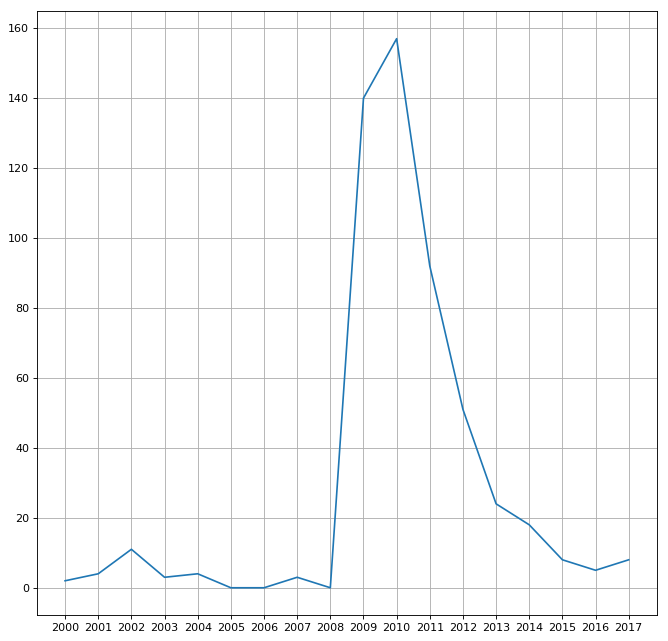

```python
import numpy as np

BankFL =[count00,count01,count02,count03,count04,count05,count06,count07,count08,count09,count10,count11,count12,count13,count14,count15,count16,count17]
year = list(range(2000,2018))

import matplotlib.pyplot as plt
from matplotlib.pyplot import figure
figure(num=None, figsize=(10, 10), dpi=80, facecolor='w', edgecolor='k')
plt.plot(year,BankFL)
plt.grid(True)
plt.xticks(np.arange(min(year), max(year)+1, 1.0))
```

it can be seen that there were some bank failures up to 2002 probably due to the 2000 recession after that point bank failures decreased to 0, until the great recesion where bank failures skyrocketed to reach its max on 2010 and reach a smaller number to 2016.

## 2) Top buyers by state

```python
from collections import Counter


dictionarylist = Counter(df['Acquiring Institution'])

#print(dictionarylist.most_common())
for k, v in dictionarylist.most_common(6):
    print ('%s: %i' % (k, v))

#lol = dictionarylist.get("No Acquirer")
#print(lol)

#top buyer institutions
```

```
No Acquirer: 31
State Bank and Trust Company: 12
First-Citizens Bank & Trust Company: 11
Ameris Bank: 10
U.S. Bank N.A.: 9
Community & Southern Bank: 8
```

```python
bank1 = []
bank2 = []
bank3 = []
bank4 = []
bank5 = []
for i in range(0,555):
    if(df['Acquiring Institution'][i] == "State Bank and Trust Company"):
        bank1.append(df['ST'][i])
    if(df['Acquiring Institution'][i] == "State Bank and Trust Company"):
        bank1.append(df['ST'][i])
    elif (df['Acquiring Institution'][i] == "First-Citizens Bank & Trust Company"):
        bank2.append(df['ST'][i])
    elif (df['Acquiring Institution'][i] == "Ameris Bank"):
        bank3.append(df['ST'][i])
    elif (df['Acquiring Institution'][i] == "U.S. Bank N.A."):
        bank4.append(df['ST'][i])
    elif (df['Acquiring Institution'][i] == "Community & Southern Bank"):
        bank5.append(df['ST'][i])

bank1
bank2
bank3
bank4
bank5
```

```
['GA', 'GA', 'GA', 'GA', 'GA', 'GA', 'GA', 'GA']
```

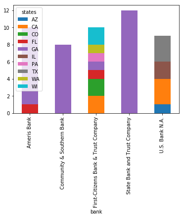

```python
import pandas as pd
%matplotlib inline

data = [
    ['State Bank and Trust Company', 'GA', 12],
    ['First-Citizens Bank & Trust Company', 'WI', 2],
    ['First-Citizens Bank & Trust Company', 'PA', 1],
    ['First-Citizens Bank & Trust Company', 'GA', 1],
    ['First-Citizens Bank & Trust Company', 'CO', 2],
    ['First-Citizens Bank & Trust Company', 'FL', 1],
    ['First-Citizens Bank & Trust Company', 'CA', 2],
    ['First-Citizens Bank & Trust Company', 'WA', 1],
    ['Ameris Bank', 'GA', 9],
    ['Ameris Bank', 'FL', 1],
    ['U.S. Bank N.A.', 'TX', 3],
    ['U.S. Bank N.A.', 'IL', 2],
    ['U.S. Bank N.A.', 'CA', 3],
    ['U.S. Bank N.A.', 'AZ', 1],
    ['Community & Southern Bank', 'GA', 8],
]

df1 = pd.DataFrame(data, columns=['bank', 'states', 'count'])
figure(num=None, figsize=(15, 15), dpi=90, facecolor='w', edgecolor='k')

pt = df1.pivot('bank', 'states', 'count')

pt.plot(kind='bar', stacked=True)
```

## 3) Bank failure per month

```python
#for k, v in month.items(): print(k, v)
```

```python
# we have to rerun this cell and the thenxt after running the entire project.
import datetime

datee =[]
dateem = []

for i in range(0,555):
    datee.append(datetime.datetime.strptime(df['Closing Date'][i], "%Y-%m-%d"))
    dateem.append(datee[i].month)


month = Counter(dateem)
month2 = dict(month)


month
```

```
Counter({12: 35,
         10: 59,
         5: 43,
         4: 59,
         3: 40,
         1: 51,
         9: 38,
         8: 41,
         7: 74,
         2: 44,
         11: 35,
         6: 36})
```

```python
month3 = sorted(month2.items(), key=lambda x: x[0])
dict(month3)
```

```
{1: 51,
 2: 44,
 3: 40,
 4: 59,
 5: 43,
 6: 36,
 7: 74,
 8: 41,
 9: 38,
 10: 59,
 11: 35,
 12: 35}
```

```python
import plotly.graph_objs as go
data = [
    go.Scatterpolar(
      r = [51, 0, 0, 0, 0, 0,0,0,0,0,0,0],
      theta = ['Jan','Feb','Mar', 'April', 'May', 'Jun','Jul' , 'Aug','Sep','Oct', 'Nov','Dec'],
      fill = 'toself',
        name= "Jan"
),

        go.Scatterpolar(
      r = [0,44, 0, 0, 0, 0,0,0,0,0,0,0],
      theta = ['Jan','Feb','Mar', 'April', 'May', 'Jun','Jul' , 'Aug','Sep','Oct', 'Nov','Dec'],
      fill = 'toself',
        name= "Feb"
),

        go.Scatterpolar(
      r = [0, 0, 40, 0, 0, 0,0,0,0,0,0,0],
      theta = ['Jan','Feb','Mar', 'April', 'May', 'Jun','Jul' , 'Aug','Sep','Oct', 'Nov','Dec'],
      fill = 'toself',
        name= "Mar"
),

        go.Scatterpolar(
      r = [0, 0, 0, 59, 0, 0,0,0,0,0,0,0],
      theta = ['Jan','Feb','Mar', 'April', 'May', 'Jun','Jul' , 'Aug','Sep','Oct', 'Nov','Dec'],
      fill = 'toself',
        name= "Apr"
),

            go.Scatterpolar(
      r = [0, 0, 0, 0, 43, 0,0,0,0,0,0,0],
      theta = ['Jan','Feb','Mar', 'April', 'May', 'Jun','Jul' , 'Aug','Sep','Oct', 'Nov','Dec'],
      fill = 'toself',
        name= "May"
),

            go.Scatterpolar(
      r = [0, 0, 0, 0, 0, 36,0,0,0,0,0,0],
      theta = ['Jan','Feb','Mar', 'April', 'May', 'Jun','Jul' , 'Aug','Sep','Oct', 'Nov','Dec'],
      fill = 'toself',
        name= "Jun"
),
               go.Scatterpolar(
      r = [0, 0, 0, 0, 0, 0,74,0,0,0,0,0],
      theta = ['Jan','Feb','Mar', 'April', 'May', 'Jun','Jul' , 'Aug','Sep','Oct', 'Nov','Dec'],
      fill = 'toself',
        name= "Jul"
),
               go.Scatterpolar(
      r = [0, 0, 0, 0, 0, 0,0,41,0,0,0,0],
      theta = ['Jan','Feb','Mar', 'April', 'May', 'Jun','Jul' , 'Aug','Sep','Oct', 'Nov','Dec'],
      fill = 'toself',
        name= "Aug"
),
               go.Scatterpolar(
      r = [0, 0, 0, 0, 0, 0,0,0,38,0,0,0],
      theta = ['Jan','Feb','Mar', 'April', 'May', 'Jun','Jul' , 'Aug','Sep','Oct', 'Nov','Dec'],
      fill = 'toself',
        name= "Sept"
),

        go.Scatterpolar(
      r = [0, 0, 0, 0, 0, 0,0,0,0,59,0,0],
      theta = ['Jan','Feb','Mar', 'April', 'May', 'Jun','Jul' , 'Aug','Sep','Oct', 'Nov','Dec'],
      fill = 'toself',
        name= "Oct"
),
               go.Scatterpolar(
      r = [0, 0, 0, 0, 0, 0,0,0,0,0,35,0],
      theta = ['Jan','Feb','Mar', 'April', 'May', 'Jun','Jul' , 'Aug','Sep','Oct', 'Nov','Dec'],
      fill = 'toself',
        name= "Nov"
),
               go.Scatterpolar(
      r = [0, 0, 0, 0, 0, 0,0,0,0,0,0,35],
      theta = ['Jan','Feb','Mar', 'April', 'May', 'Jun','Jul' , 'Aug','Sep','Oct', 'Nov','Dec'],
      fill = 'toself',
        name= "Dec"
),


]

layout = go.Layout(
  polar = dict(
    radialaxis = dict(
      visible = True,
      range = [0, 80]
    )
  ),
  showlegend = True
)

fig1 = go.Figure(data=data, layout=layout)
py.iplot( fig1, filename='per month' )
```

[interactive chart not shown]

As it can be seen the highest bank failure months are January, April, July,and October. I could Assume that is related to the way handle accaountacy by updating their books per begining quarter. On the begining of Q1 we have January, on Q2 we have April, on Q3 we have July and on Q4 we have october. All of these months math the begining of finacial quarters.

## 4) bank failure per state

```python
#test = df["ST"].values.tolist
```

```python
STATE = Counter(df['ST'])
type(STATE)
len(STATE)
```

```
44
```

```python
STATE = dict(STATE)

STATE
keys = list(STATE.keys())
values = list(STATE.values())
#keys
#values
```

```python
import plotly
plotly.tools.set_credentials_file(username='vmelednezg2', api_key='WYuZ0x5v2VOgHN5I6RCX')
```

```python
import plotly.plotly as py
import pandas as pd


for col in df.columns:
    df[col] = df[col].astype(str)

scl = [[0.0, 'rgb(242,240,247)'],[0.2, 'rgb(218,218,235)'],[0.4, 'rgb(188,189,220)'],\
            [0.6, 'rgb(158,154,200)'],[0.8, 'rgb(130,130,177)'],[1.0, 'rgb(100,80,143)']]


data = [ dict(
        type='choropleth',
        colorscale = scl,
        autocolorscale = False,
        locations = keys,
        z = values,
        locationmode = 'USA-states',
        text = keys,
        marker = dict(
            line = dict (
                color = 'rgb(255,255,255)',
                width = 2
            ) ),
        colorbar = dict(
            title = "number of Bank Failures")
        ) ]

layout = dict(
        title = 'Bank Failures per US State',
        geo = dict(
            scope='usa',
            projection=dict( type='albers usa' ),
            showlakes = True,
            lakecolor = 'rgb(255, 255, 255)'),
             )

fig = dict( data=data, layout=layout )
py.iplot( fig, filename='d3-cloropleth-map' )


#its hard to see but hawaii is there just is too ligth be seen.
```

```
High five! You successfully sent some data to your account on plotly. View your plot in your browser at https://plot.ly/~vmelednezg2/0 or inside your plot.ly account where it is named 'd3-cloropleth-map'
```

[interactive chart not shown]

## 5) No acquisitions analysis

```python
Noq = []
for i in range(0,555):
    if(df['Acquiring Institution'][i] == "No Acquirer"):
        Noq.append(df['ST'][i])
No1 = Counter(Noq)
print(No1)
print(STATE)
```

[output not shown]

```python
datee1 =[]
dateey = []

for i in range(0,555):
    if(df['Acquiring Institution'][i] == "No Acquirer"):
        datee1.append(datetime.datetime.strptime(df['Closing Date'][i], "%Y-%m-%d")) and dateey.append(datee1[i].year)
lal=[]
for i in range(0,len(datee1)):
     lal.append(datee1[i].year)

YEAR = Counter(lal)
YEAR
```

```
Counter({2013: 1, 2012: 4, 2011: 2, 2010: 8, 2009: 11, 2004: 1, 2002: 4})
```

## 6) Why Failure in Specific states

Based on the map we can see that there are 3 states that seem to be outliers to the situation those are Georgia, Florida, and Illinios:

For Georgia there are several reasons why the bank failure was so high: The main reasons are that Atlanta did not had problems with a price bubble, but over construction due to low construction permit requirements and easy to construct land. As, a result when the financial crisis came, banks ended up with a lot of inventory assets (houses) these assets we fixed and hard to convert to cash. In addition, around 5% of Georgia’s economy was dependent on the construction industry, when the housing market hit Georgia it took a heavier hit than other states.

Florida: In Florida they suffered a similar fate to Georgia, many small communities in Florida were dependent on the construction industry and since, there were low construction requirements there was a lot of over building. However, the situation was worse on Florida because there was a huge price bubble too, Houses doubled and tripled in their value, which when the market crashed the value of assets went down at a critical rate.

Illinois: The problem in Illinois was that mortgages were readily available more than other states, when the recession hit, at least 30% of homeowner went under water on their debt, and house value plummet to alarming rates. The main is that recovery in Illinois has been sluggish compared to other states.